# WeRateDogs Report

### by Xi Palazzolo

```python
from IPython.display import HTML

HTML('''<script>
code_show=true;
function code_toggle() {
 if (code_show){
 $('div.input').hide();
 } else {
 $('div.input').show();
 }
 code_show = !code_show
}
$( document ).ready(code_toggle);
</script>
<form action="javascript:code_toggle()"><input type="submit" value="Show Code"></form>''')
```

#### Overview of Project

This report is generated using data from Twitter users @dog_rates, also known as WeRateDogs. WeRateDogs is a Twitter account that rates people's dogs with a humorous comment about the dog. These ratings almost always have a denominator of 10. One thing special about this rating is that usually the rating numerator is greater or equal than 10. WeRateDogs has over 4 million followers and has received international media coverage. In this report, only tweets before August 1, 2017 were gathered and analyzed.

#### Findings and Insights

Between January of 2015 and August of 2017, there were 1968 Twitter users tweeted their dog's pictures for the WeRateDogs event. Most Twitter users tweetedd their dog pictures in 2017.

**Retweets** <br> Of these tweets, one picture was retweeted 77,886 times with a rating of 13/10. There is another puppy whose picture was favorited for 144,060 times (picture shown below) and also received a rating of 13/10.

<img src="favorited_Most_puppy.jpg" title = 'My picture got favorited 144,060 times on Twitter!'/>

**Ratings**  
Twitter users love their dogs. Of these tweets that were analyzed, it turns out one puppy received a rating of 98/10. Want to see how cute this floof is? Here he is, Yogi.

[figure not shown]

**Dog Stages**  
There are 351 Tweeter users gave inforamtion on their dog stages (definitions are based on those given by Dogtionary). Below is a breakdown of the stages. About 64%(225/351) of dogs are pupper while no dog is snoot.

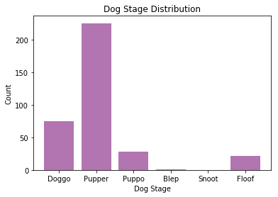

```python
import seaborn as sns
import pandas as pd
import numpy as np
import matplotlib.pyplot as plt
%matplotlib inline
count = [75, 225, 28, 1, 0, 22]
stage = ['Doggo', 'Pupper', 'Puppo', 'Blep', 'Snoot', 'Floof']
y_pos = np.arange(len(stage))
plt.bar(range(len(stage)), count,  color = (0.5,0.1,0.5,0.6))
plt.xticks(range(len(stage)), stage)
plt.xlabel('Dog Stage')
plt.ylabel('Count')
plt.title('Dog Stage Distribution')
plt.show()
```

**Tweet Day VS Retweet Counts**  
Is there a relationship between the day of week when someone tweeted a dog picture and the retweet counts it got? From the scatterplot below, it doesn't seem to have a trend where tweet day affect retweet count. Our linear regression model also confirm that.

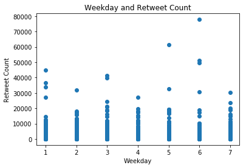

```python
from sklearn.linear_model import LinearRegression
df=pd.read_csv('twitter_archive_master.csv')
plt.scatter(x= df['Weekday'], y = df['Retweet_Count'])
plt.xlabel('Weekday')
plt.ylabel('Retweet Count')
plt.title('Weekday and Retweet Count')
plt.show()
```

```
Model slope:     14.036569407553777
Model intercept: 2697.314823093649
```

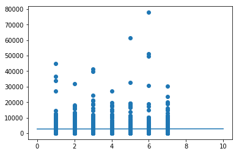

```python
x = df['Weekday']
y = df['Retweet_Count']
model = LinearRegression(fit_intercept=True)
model.fit(x[:, np.newaxis], y)
xfit = np.linspace(0, 10, 1000)
yfit = model.predict(xfit[:, np.newaxis])

plt.scatter(x, y)
plt.plot(xfit, yfit)
print("Model slope:    ", model.coef_[0])
print("Model intercept:", model.intercept_)
```

**Tweet Day VS Favorite Counts**  
Is there a relationship between the day of week when someone tweeted a dog picture and the favorite counts it got? From the scatterplot below, it doesn't seem to have a trend where tweet day affect favorite count. Our linear regression model also confirm that.

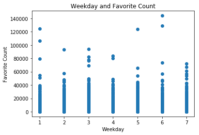

```python
from sklearn.linear_model import LinearRegression
df=pd.read_csv('twitter_archive_master.csv')
plt.scatter(x= df['Weekday'], y = df['Favorite_Count'])
plt.xlabel('Weekday')
plt.ylabel('Favorite Count')
plt.title('Weekday and Favorite Count')
plt.show()
```

```
Model slope:     -14.454262702722161
Model intercept: 8970.052221427783
```

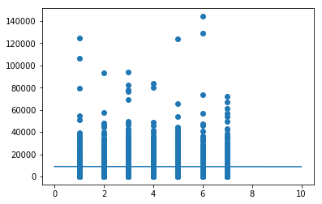

```python
x = df['Weekday']
y = df['Favorite_Count']
model = LinearRegression(fit_intercept=True)
model.fit(x[:, np.newaxis], y)
xfit = np.linspace(0, 10, 1000)
yfit = model.predict(xfit[:, np.newaxis])

plt.scatter(x, y)
plt.plot(xfit, yfit)
print("Model slope:    ", model.coef_[0])
print("Model intercept:", model.intercept_)
```